# Figure S2: ATP and pH controls

# Fig S2A

Mitochondrial pH under control and homeostatic-plasticity conditions in wild-type neurons.

**Source data**  
`Fig S2A.csv`

**Columns**

- `Date` — Experiment date
- `Condition` — Control or TTX
- `Dish` — Culture dish ID
- `Cell` — Cell ID
- `Mito_ID` — Mitochondrial trace ID
- `Frame` — Imaging frame
- `Intensity` — pH sensor fluorescence

## Data

pH is estimated per trace using mean fluorescence over the first ten frames, peak fluorescence, pKa 7.1, and a reference pH of 7.4.

```r
suppressPackageStartupMessages({
  library(dplyr); library(readr); library(ggplot2); library(ggbeeswarm); library(ggtext)
})

pKa <- 7.1
spacing_map <- c(Control = 1, TTX = 2.2)

pH_frames <- read_csv("./Fig S2A.csv", show_col_types = FALSE) %>%
  select(Date, Condition, Dish, Cell, Mito_ID, Frame, Intensity) %>%
  mutate(Date = trimws(as.character(Date)), Condition = trimws(as.character(Condition)),
         Frame = as.numeric(Frame), Intensity = as.numeric(Intensity)) %>%
  filter(Condition %in% names(spacing_map), Date != "", is.finite(Frame),
         is.finite(Intensity)) %>%
  group_by(Date, Condition, Dish, Cell, Mito_ID, Frame) %>%
  summarise(Intensity = mean(Intensity), .groups = "drop")

pH_summary_Mito <- pH_frames %>%
  group_by(Date, Condition, Dish, Cell, Mito_ID) %>%
  summarise(F0 = mean(Intensity[Frame %in% head(sort(unique(Frame)), 10)]),
            Fmax = max(Intensity), n_Frames = n_distinct(Frame), .groups = "drop") %>%
  filter(n_Frames >= 10, F0 > 0, Fmax > 0) %>%
  mutate(Mito_pH = pKa - log10((1 + 10^(pKa - 7.4)) / (F0 / Fmax) - 1)) %>%
  filter(is.finite(Mito_pH)) %>%
  mutate(Date = factor(Date), Condition = factor(Condition, levels = names(spacing_map)),
         DateCondition = paste(Condition, Date, sep = "_"),
         x_pos = unname(spacing_map[as.character(Condition)]))

if (n_distinct(pH_summary_Mito$Condition) < 2 || n_distinct(pH_summary_Mito$Date) < 2)
  stop("Both conditions and at least two dates are required.")

pH_summary_Mito %>% select(Date, Condition, Dish, Cell, Mito_ID, Mito_pH) %>%
  mutate(Mito_pH = round(Mito_pH, 3))
```

| Date | Condition | Dish | Cell | Mito_ID | Mito_pH |
| --- | --- | --- | --- | --- | --- |
| 2025-06-25 | Control | 1 | 1 | 1 | 7.208 |
| 2025-06-25 | Control | 1 | 1 | 2 | 7.030 |
| 2025-06-25 | Control | 1 | 1 | 3 | 7.146 |
| 2025-06-25 | Control | 1 | 1 | 4 | 7.099 |
| 2025-06-25 | Control | 1 | 1 | 5 | 7.114 |
| 2025-06-25 | Control | 1 | 1 | 6 | 6.993 |
| 2025-06-25 | Control | 2 | 1 | 1 | 7.102 |
| 2025-06-25 | Control | 2 | 1 | 2 | 7.227 |
| 2025-06-25 | Control | 2 | 1 | 3 | 7.005 |
| 2025-06-25 | Control | 2 | 1 | 4 | 6.913 |

[output cut: 134 more lines]

## Summary

```r
summary_table <- pH_summary_Mito %>% group_by(Condition) %>%
  summarise(n_Mitochondria = n(), n_Cells = n_distinct(Date, Dish, Cell),
            n_Experiment_Dates = n_distinct(Date),
            `Mean (SE)` = sprintf("%.3f (%.3f)", mean(Mito_pH),
                                  sd(Mito_pH) / sqrt(n())), .groups = "drop")
summary_table
```

| Condition | n_Mitochondria | n_Cells | n_Experiment_Dates | Mean (SE) |
| --- | --- | --- | --- | --- |
| Control | 73 | 8 | 3 | 7.084 (0.016) |
| TTX | 71 | 7 | 3 | 7.083 (0.009) |

## Statistics

Two-way ANOVA with condition, experiment date, and their interaction (Type I sums of squares).

```r
fit_aov <- aov(Mito_pH ~ Condition * Date, data = pH_summary_Mito)
condition_p <- as.numeric(anova(fit_aov)["Condition", "Pr(>F)"])
format_p <- function(p) ifelse(p < 0.0001, "<0.0001", sprintf("%.4f", p))

stats_table <- tibble(
  Test = "Two-way ANOVA", Comparison = "Control vs TTX",
  `Control mean (SE)` = summary_table$`Mean (SE)`[summary_table$Condition == "Control"],
  `TTX mean (SE)` = summary_table$`Mean (SE)`[summary_table$Condition == "TTX"],
  `Condition p` = format_p(condition_p)
)
stats_table
```

| Test | Comparison | Control mean (SE) | TTX mean (SE) | Condition p |
| --- | --- | --- | --- | --- |
| Two-way ANOVA | Control vs TTX | 7.084 (0.016) | 7.083 (0.009) | 0.9497 |

```r
anova(fit_aov)
```

|  | Df | Sum Sq | Mean Sq | F value | Pr(>F) |
| --- | --- | --- | --- | --- | --- |
| Condition | 1 | 0.0000479589 | 0.0000479589 | 0.003997744 | 0.949676666 |
| Date | 2 | 0.1553343369 | 0.0776671684 | 6.474156871 | 0.002053556 |
| Condition:Date | 2 | 0.0045732049 | 0.0022866025 | 0.190605933 | 0.826675410 |
| Residuals | 138 | 1.6555158388 | 0.0119964916 | NA | NA |

## Plot

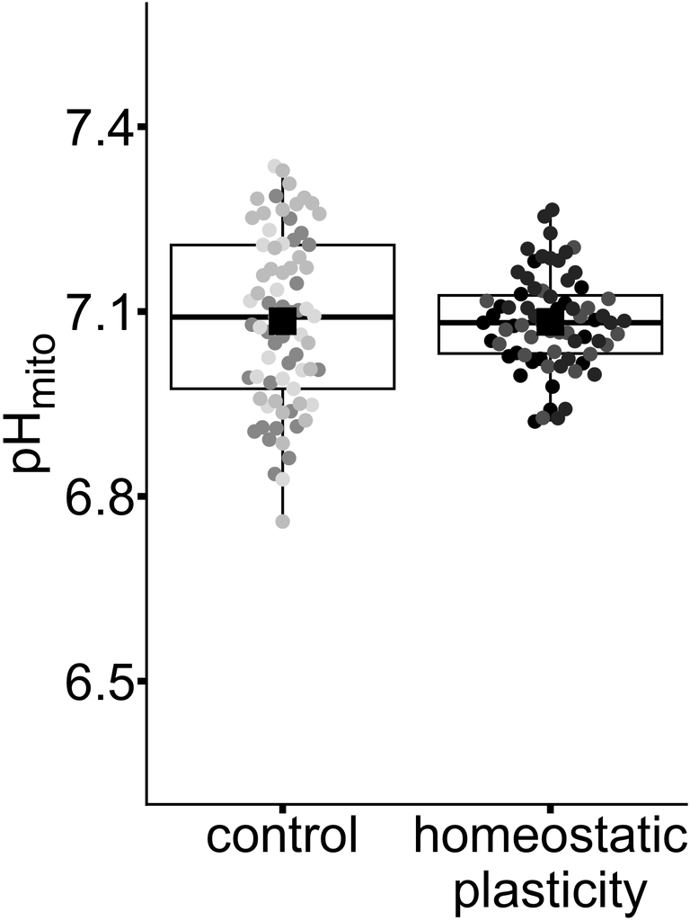

```r
set.seed(20261109)
date_levels <- levels(pH_summary_Mito$Date)
date_colors <- c(
  setNames(rep(c("#999999", "#E0E0E0", "#C8C8C8"), length.out = length(date_levels)),
           paste("Control", date_levels, sep = "_")),
  setNames(rep(c("#000000", "#606060", "#303030"), length.out = length(date_levels)),
           paste("TTX", date_levels, sep = "_"))
)
test_results <- tibble(
  group1_x = spacing_map["Control"], group2_x = spacing_map["TTX"], y_position = 7.48,
  stars = case_when(condition_p < 0.001 ~ "***", condition_p < 0.01 ~ "**",
                    condition_p < 0.05 ~ "*", TRUE ~ "ns")
) %>% filter(stars != "ns")

figs2a_plot <- ggplot(pH_summary_Mito, aes(x_pos, Mito_pH, color = DateCondition)) +
  geom_boxplot(aes(group = x_pos), fill = NA, width = 1, outlier.shape = NA,
               linewidth = 2, color = "black") +
  ggbeeswarm::geom_beeswarm(cex = 3, priority = "random", size = 10, corral = "random") +
  stat_summary(aes(group = x_pos), fun = mean, geom = "point",
               shape = 15, size = 20, color = "black") +
  geom_segment(data = test_results,
               aes(x = group1_x, xend = group2_x, y = y_position, yend = y_position),
               inherit.aes = FALSE, linewidth = 2, color = "black") +
  geom_text(data = test_results,
            aes(x = (group1_x + group2_x) / 2, y = y_position + 0.04, label = stars),
            inherit.aes = FALSE, size = 25, color = "black") +
  scale_x_continuous(breaks = unname(spacing_map),
                     labels = c("control", "homeostatic\nplasticity")) +
  scale_y_continuous(oob = scales::oob_keep, breaks = c(6.5, 6.8, 7.1, 7.4),
                     limits = c(6.3, 7.6), expand = c(0, 0)) +
  scale_color_manual(values = date_colors) +
  labs(x = NULL, y = "pH<sub>mito</sub>") +
  theme_classic() +
  theme(axis.title.y = ggtext::element_markdown(size = 80, color = "black"),
        axis.text = element_text(size = 80, color = "black"),
        axis.ticks = element_line(linewidth = 5, color = "black"),
        axis.ticks.length = grid::unit(0.5, "cm"),
        axis.line = element_line(linewidth = 2, color = "black"),
        legend.position = "none")
figs2a_plot
```

# Fig S2B

Mitochondrial pH after MPC1 knockdown under control and homeostatic-plasticity conditions.

**Source data**  
`Fig S2B.csv`

**Columns**

- `Date` — Experiment date
- `Condition` — Control or TTX after MPC1 knockdown
- `Dish` — Culture dish ID
- `Cell` — Cell ID
- `Mito_ID` — Mitochondrial trace ID
- `Frame` — Imaging frame
- `Intensity` — pH sensor fluorescence

## Data

pH is estimated per trace using mean fluorescence over the first ten frames, peak fluorescence, pKa 7.1, and a reference pH of 7.4.

```r
suppressPackageStartupMessages({
  library(dplyr); library(readr); library(ggplot2); library(ggbeeswarm); library(ggtext)
})

spacing_map <- c("Control MPC1KD" = 1, "TTX MPC1KD" = 2.2)
pKa <- 7.1

pH_df <- read_csv("./Fig S2B.csv", show_col_types = FALSE) %>%
  filter(Condition %in% names(spacing_map), is.finite(Frame), is.finite(Intensity)) %>%
  group_by(Date, Condition, Dish, Cell, Mito_ID, Frame) %>%
  summarise(Intensity = mean(Intensity), .groups = "drop")

mito_df <- pH_df %>%
  group_by(Date, Condition, Dish, Cell, Mito_ID) %>%
  summarise(n_Frames = n_distinct(Frame),
            F0 = mean(Intensity[Frame %in% head(sort(unique(Frame)), 10)]),
            Fmax = max(Intensity), .groups = "drop") %>%
  filter(n_Frames >= 10, F0 > 0, Fmax > 0) %>%
  mutate(Mito_pH = pKa - log10((1 + 10^(pKa - 7.4)) / (F0 / Fmax) - 1)) %>%
  filter(is.finite(Mito_pH)) %>%
  mutate(Condition = factor(Condition, levels = names(spacing_map)),
         Date = factor(Date), x_pos = unname(spacing_map[as.character(Condition)]),
         Date_Condition = paste(Condition, Date, sep = "_"))

if (nrow(mito_df) == 0) stop("No valid mitochondria remain.")
mito_df %>% transmute(Date, Condition, Dish, Cell, Mito_ID, Mito_pH = round(Mito_pH, 3))
```

| Date | Condition | Dish | Cell | Mito_ID | Mito_pH |
| --- | --- | --- | --- | --- | --- |
| 2026-05-28 | Control MPC1KD | 2 | 1 | 1 | 7.165 |
| 2026-05-28 | Control MPC1KD | 2 | 1 | 2 | 7.116 |
| 2026-05-28 | Control MPC1KD | 2 | 1 | 3 | 7.113 |
| 2026-05-28 | Control MPC1KD | 2 | 1 | 4 | 7.292 |
| 2026-05-28 | Control MPC1KD | 2 | 1 | 5 | 7.275 |
| 2026-05-28 | Control MPC1KD | 2 | 1 | 6 | 7.178 |
| 2026-05-28 | Control MPC1KD | 2 | 1 | 7 | 7.035 |
| 2026-05-28 | Control MPC1KD | 2 | 1 | 8 | 7.066 |
| 2026-05-28 | Control MPC1KD | 2 | 1 | 9 | 6.986 |
| 2026-05-28 | Control MPC1KD | 2 | 1 | 10 | 6.882 |

[output cut: 159 more lines]

## Summary

```r
summary_table <- mito_df %>%
  group_by(Condition) %>%
  summarise(n_Mitochondria = n(), n_Cells = n_distinct(Date, Dish, Cell),
            n_Experiment_Dates = n_distinct(Date), .groups = "drop")
summary_table
```

| Condition | n_Mitochondria | n_Cells | n_Experiment_Dates |
| --- | --- | --- | --- |
| Control MPC1KD | 84 | 6 | 3 |
| TTX MPC1KD | 85 | 6 | 3 |

## Statistics

Two-way ANOVA with condition, experiment date, and their interaction (Type I sums of squares).

```r
fit_aov <- aov(Mito_pH ~ Condition * Date, data = mito_df)
condition_p <- as.numeric(anova(fit_aov)["Condition", "Pr(>F)"])
format_p <- function(p) ifelse(p < 0.0001, "<0.0001", sprintf("%.4f", p))

means <- mito_df %>% group_by(Condition) %>%
  summarise(mean = mean(Mito_pH), SE = sd(Mito_pH) / sqrt(n()), .groups = "drop")
stats_table <- tibble(
  Test = "Two-way ANOVA", Comparison = "Control MPC1KD vs TTX MPC1KD",
  `Control mean (SE)` = sprintf("%.3f (%.3f)", means$mean[1], means$SE[1]),
  `TTX mean (SE)` = sprintf("%.3f (%.3f)", means$mean[2], means$SE[2]),
  `Condition p` = format_p(condition_p)
)
stats_table
```

| Test | Comparison | Control mean (SE) | TTX mean (SE) | Condition p |
| --- | --- | --- | --- | --- |
| Two-way ANOVA | Control MPC1KD vs TTX MPC1KD | 7.080 (0.022) | 7.076 (0.018) | 0.8888 |

```r
anova(fit_aov)
```

|  | Df | Sum Sq | Mean Sq | F value | Pr(>F) |
| --- | --- | --- | --- | --- | --- |
| Condition | 1 | 0.0006371075 | 0.0006371075 | 0.01960495 | 0.88881889 |
| Date | 2 | 0.0295596532 | 0.0147798266 | 0.45480194 | 0.63537643 |
| Condition:Date | 2 | 0.2262575219 | 0.1131287609 | 3.48117615 | 0.03307821 |
| Residuals | 163 | 5.2970568678 | 0.0324972814 | NA | NA |

## Plot

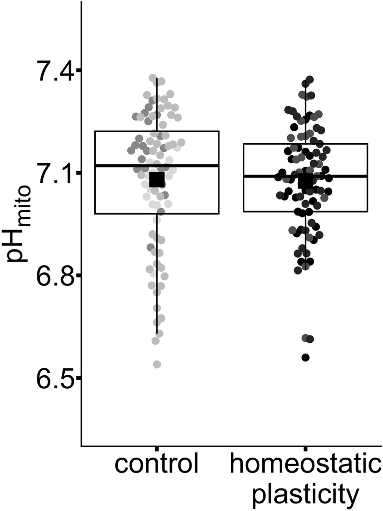

```r
set.seed(20261109)
date_levels <- levels(mito_df$Date)
date_colors <- c(
  setNames(rep(c("#999999", "#E0E0E0", "#C8C8C8"), length.out = length(date_levels)),
           paste("Control MPC1KD", date_levels, sep = "_")),
  setNames(rep(c("#000000", "#606060", "#303030"), length.out = length(date_levels)),
           paste("TTX MPC1KD", date_levels, sep = "_"))
)
stars <- case_when(condition_p < 0.001 ~ "***", condition_p < 0.01 ~ "**",
                   condition_p < 0.05 ~ "*", TRUE ~ "ns")
plot_stats <- tibble(x1 = 1, x2 = 2.2, y = 7.48, stars = stars) %>% filter(stars != "ns")

figs2b_plot <- ggplot(mito_df, aes(x_pos, Mito_pH, color = Date_Condition)) +
  ggbeeswarm::geom_beeswarm(cex = 3, priority = "random", size = 10, corral = "random") +
  geom_boxplot(aes(group = x_pos), fill = NA, width = 1, outlier.shape = NA,
               linewidth = 2, color = "black") +
  stat_summary(aes(group = x_pos), fun = mean, geom = "point",
               shape = 15, size = 20, color = "black") +
  geom_segment(data = plot_stats, aes(x = x1, xend = x2, y = y, yend = y),
               inherit.aes = FALSE, linewidth = 2, color = "black") +
  geom_text(data = plot_stats, aes(x = (x1 + x2) / 2, y = y + 0.04, label = stars),
            inherit.aes = FALSE, size = 25, color = "black") +
  scale_x_continuous(breaks = unname(spacing_map),
                     labels = c("control", "homeostatic\nplasticity")) +
  scale_y_continuous(oob = scales::oob_keep, breaks = c(6.5, 6.8, 7.1, 7.4),
                     limits = c(6.3, 7.6), expand = c(0, 0)) +
  scale_color_manual(values = date_colors) +
  labs(x = NULL, y = "pH<sub>mito</sub>") +
  theme_classic() +
  theme(axis.title.y = ggtext::element_markdown(size = 80, color = "black"),
        axis.text = element_text(size = 80, color = "black"),
        axis.ticks = element_line(linewidth = 5, color = "black"),
        axis.ticks.length = grid::unit(0.5, "cm"),
        axis.line = element_line(linewidth = 2, color = "black"),
        legend.position = "none")
figs2b_plot
```

# Fig S2C

Axonal mitochondrial ATP reporter L/F following homeostatic plasticity.

**Source data**  
`Fig S2C.csv`

**Columns**

- `Date` — Experiment date
- `Condition` — Control or TTX
- `Dish` — Culture dish ID
- `Cell` — Cell ID
- `Mito` — Mitochondrion ID
- `Slice` — Image slice ID
- `L` — Luciferase luminescence
- `F` — Reporter fluorescence
- `LbyF` — Luminescence-to-fluorescence ratio (L/F)

## Data

```r
suppressPackageStartupMessages({
  library(dplyr); library(readr); library(ggplot2); library(ggbeeswarm); library(ggtext)
})

PLOT_CORRECTED <- TRUE
spacing_map <- c(Control = 1, TTX = 2.2)
pH_control <- 6.97; pH_scaling <- 6.91; pKa_L <- 7.03
L_corr_factor <- (1 + 10^(pKa_L - pH_scaling)) / (1 + 10^(pKa_L - pH_control))
plot_y <- if (PLOT_CORRECTED) "LbyF_corrected" else "LbyF"

LbyF_df <- read_csv("./Fig S2C.csv", show_col_types = FALSE) %>%
  mutate(Condition = trimws(as.character(Condition)),
         LbyF_corrected = if_else(Condition == "TTX", L * L_corr_factor / F, L / F)) %>%
  filter(Condition %in% names(spacing_map), !is.na(Date), is.finite(.data[[plot_y]])) %>%
  mutate(Condition = factor(Condition, levels = names(spacing_map)),
         Date = factor(Date), x_pos = unname(spacing_map[as.character(Condition)]),
         Date_Condition = paste(Condition, Date, sep = "_"))

if (nrow(LbyF_df) == 0) stop("No valid axonal mitochondria remain.")
LbyF_df %>%
  select(Date, Condition, Cell, any_of(c("Mito", "Mito_ID")), L, F, LbyF, LbyF_corrected) %>%
  mutate(across(where(is.numeric), ~ round(.x, 3)))
```

| Date | Condition | Cell | Mito | L | F | LbyF | LbyF_corrected |
| --- | --- | --- | --- | --- | --- | --- | --- |
| 2025-07-07 | Control | 1 | 1 | 18.158 | 133.789 | 0.136 | 0.136 |
| 2025-07-07 | Control | 1 | 2 | 32.333 | 155.944 | 0.207 | 0.207 |
| 2025-07-07 | Control | 1 | 3 | 29.333 | 127.667 | 0.230 | 0.230 |
| 2025-07-07 | Control | 1 | 4 | 32.647 | 177.588 | 0.184 | 0.184 |
| 2025-07-07 | Control | 2 | 1 | 41.048 | 323.524 | 0.127 | 0.127 |
| 2025-07-07 | Control | 2 | 2 | 29.438 | 505.000 | 0.058 | 0.058 |
| 2025-07-07 | Control | 2 | 3 | 15.200 | 240.400 | 0.063 | 0.063 |
| 2025-07-07 | Control | 2 | 4 | 22.100 | 379.950 | 0.058 | 0.058 |
| 2025-07-07 | Control | 3 | 1 | 17.278 | 532.056 | 0.032 | 0.032 |
| 2025-07-07 | Control | 5 | 1 | 31.067 | 865.600 | 0.036 | 0.036 |

[output cut: 286 more lines]

## Summary

```r
summary_table <- LbyF_df %>%
  group_by(Condition) %>%
  summarise(n_Mitochondria = n(), n_Cells = n_distinct(Date, Cell),
            n_Experiment_Dates = n_distinct(Date), .groups = "drop")
summary_table
```

| Condition | n_Mitochondria | n_Cells | n_Experiment_Dates |
| --- | --- | --- | --- |
| Control | 135 | 11 | 3 |
| TTX | 161 | 10 | 3 |

## Statistics

Two-way ANOVA with condition, experiment date, and their interaction (Type I sums of squares).

```r
fit_aov <- aov(reformulate("Condition * Date", response = plot_y), data = LbyF_df)
condition_p <- as.numeric(anova(fit_aov)["Condition", "Pr(>F)"])
format_p <- function(p) ifelse(p < 0.0001, "<0.0001", sprintf("%.4f", p))

means <- LbyF_df %>% group_by(Condition) %>%
  summarise(mean = mean(.data[[plot_y]]), SE = sd(.data[[plot_y]]) / sqrt(n()), .groups = "drop")
stats_table <- tibble(
  Test = "Two-way ANOVA", Comparison = "Control vs TTX",
  `Control mean (SE)` = sprintf("%.3f (%.3f)", means$mean[1], means$SE[1]),
  `TTX mean (SE)` = sprintf("%.3f (%.3f)", means$mean[2], means$SE[2]),
  `Condition p` = format_p(condition_p)
)
stats_table
```

| Test | Comparison | Control mean (SE) | TTX mean (SE) | Condition p |
| --- | --- | --- | --- | --- |
| Two-way ANOVA | Control vs TTX | 0.135 (0.006) | 0.126 (0.004) | 0.1213 |

```r
anova(fit_aov)
```

|  | Df | Sum Sq | Mean Sq | F value | Pr(>F) |
| --- | --- | --- | --- | --- | --- |
| Condition | 1 | 0.006363678 | 0.006363678 | 2.414428 | 1.213125e-01 |
| Date | 2 | 0.209289476 | 0.104644738 | 39.703006 | 5.749573e-16 |
| Condition:Date | 2 | 0.017515657 | 0.008757829 | 3.322786 | 3.742987e-02 |
| Residuals | 290 | 0.764349532 | 0.002635688 | NA | NA |

## Plot

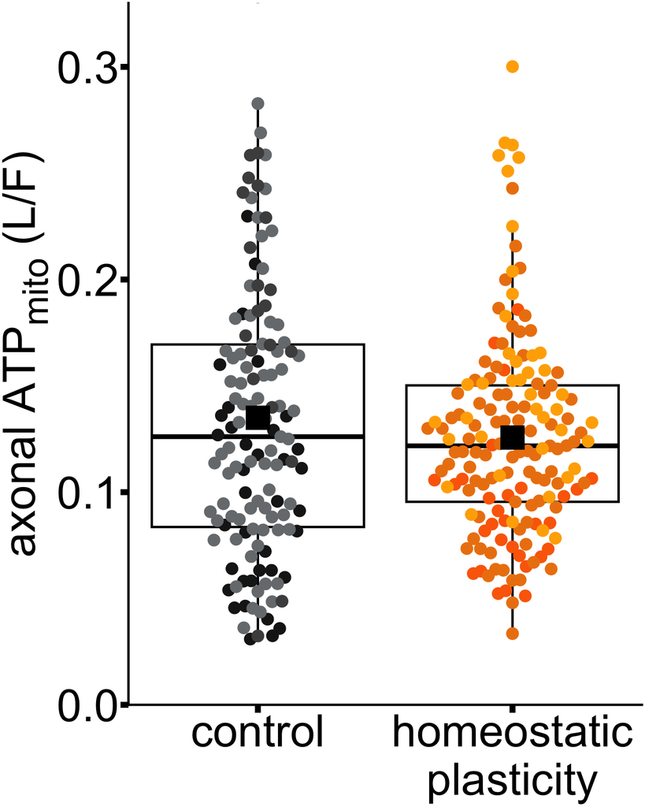

```r
set.seed(20261109)
date_levels <- levels(LbyF_df$Date)
date_colors <- c(
  setNames(rep(c("#1A1A1A", "#777B7E", "#4D4D4D"), length.out = length(date_levels)),
           paste("Control", date_levels, sep = "_")),
  setNames(rep(c("#FC6A03", "#ED820E", "#FFAD00"), length.out = length(date_levels)),
           paste("TTX", date_levels, sep = "_"))
)
stars <- case_when(condition_p < 0.001 ~ "***", condition_p < 0.01 ~ "**",
                   condition_p < 0.05 ~ "*", TRUE ~ "ns")
plot_stats <- tibble(x1 = 1, x2 = 2.2, y = 0.30, stars = stars) %>% filter(stars != "ns")

figs2c_plot <- ggplot(LbyF_df, aes(x_pos, .data[[plot_y]], color = Date_Condition)) +
  geom_boxplot(aes(group = x_pos), fill = NA, width = 1, outlier.shape = NA,
               linewidth = 2, color = "black") +
  ggbeeswarm::geom_beeswarm(cex = 3, priority = "random", size = 10, corral = "random") +
  stat_summary(aes(group = x_pos), fun = mean, geom = "point",
               shape = 15, size = 20, color = "black") +
  geom_segment(data = plot_stats, aes(x = x1, xend = x2, y = y, yend = y),
               inherit.aes = FALSE, linewidth = 2, color = "black") +
  geom_text(data = plot_stats, aes(x = (x1 + x2) / 2, y = y + 0.01, label = stars),
            inherit.aes = FALSE, size = 25, color = "black") +
  scale_x_continuous(breaks = unname(spacing_map),
                     labels = c("control", "homeostatic\nplasticity")) +
  scale_y_continuous(breaks = c(0, 0.1, 0.2, 0.3), expand = c(0, 0)) +
  scale_color_manual(values = date_colors) +
  coord_cartesian(ylim = c(0, 0.33)) +
  labs(x = NULL, y = "axonal ATP<sub>mito</sub> (L/F)") +
  theme_classic() +
  theme(axis.title.y = ggtext::element_markdown(size = 80, color = "black"),
        axis.text = element_text(size = 80, color = "black"),
        axis.ticks = element_line(linewidth = 5, color = "black"),
        axis.ticks.length = grid::unit(0.5, "cm"),
        axis.line = element_line(linewidth = 2, color = "black"),
        legend.position = "none")
figs2c_plot
```

# Fig S2D

Axonal mitochondrial pH following homeostatic plasticity.

**Source data**  
`Fig S2D.csv`

**Columns**

- `Date` — Experiment date
- `Condition` — Control or TTX
- `Dish` — Culture dish ID
- `Cell` — Cell ID
- `Mito_ID` — Mitochondrial trace ID
- `Frame` — Imaging frame
- `Intensity` — pH sensor fluorescence

## Data

pH is estimated per trace using mean fluorescence over the first ten frames, peak fluorescence, pKa 7.1, and a reference pH of 7.4.

```r
suppressPackageStartupMessages({
  library(dplyr); library(readr); library(ggplot2); library(ggbeeswarm); library(ggtext)
})

spacing_map <- c(Control = 1, TTX = 2.2)
pKa <- 7.1

pH_df <- read_csv("./Fig S2D.csv", show_col_types = FALSE) %>%
  filter(Condition %in% names(spacing_map), is.finite(Frame), is.finite(Intensity)) %>%
  group_by(Date, Condition, Dish, Cell, Mito_ID, Frame) %>%
  summarise(Intensity = mean(Intensity), .groups = "drop")

mito_df <- pH_df %>%
  group_by(Date, Condition, Dish, Cell, Mito_ID) %>%
  summarise(n_Frames = n_distinct(Frame),
            F0 = mean(Intensity[Frame %in% head(sort(unique(Frame)), 10)]),
            Fmax = max(Intensity), .groups = "drop") %>%
  filter(n_Frames >= 10, F0 > 0, Fmax > 0) %>%
  mutate(Mito_pH = pKa - log10((1 + 10^(pKa - 7.4)) / (F0 / Fmax) - 1)) %>%
  filter(is.finite(Mito_pH), Mito_pH > 0) %>%
  mutate(Condition = factor(Condition, levels = names(spacing_map)),
         Date = factor(Date), x_pos = unname(spacing_map[as.character(Condition)]),
         Date_Condition = paste(Condition, Date, sep = "_"))

if (nrow(mito_df) == 0) stop("No valid axonal mitochondria remain.")
mito_df %>% transmute(Date, Condition, Dish, Cell, Mito_ID, Mito_pH = round(Mito_pH, 3))
```

| Date | Condition | Dish | Cell | Mito_ID | Mito_pH |
| --- | --- | --- | --- | --- | --- |
| 2025-06-25 | Control | 1 | 1 | 1 | 7.146 |
| 2025-06-25 | Control | 1 | 1 | 2 | 6.838 |
| 2025-06-25 | Control | 1 | 1 | 3 | 6.954 |
| 2025-06-25 | Control | 1 | 1 | 4 | 6.873 |
| 2025-06-25 | Control | 1 | 1 | 5 | 6.815 |
| 2025-06-25 | Control | 1 | 1 | 6 | 6.873 |
| 2025-06-25 | Control | 1 | 1 | 7 | 6.885 |
| 2025-06-25 | Control | 1 | 1 | 8 | 7.032 |
| 2025-06-25 | Control | 1 | 1 | 9 | 7.123 |
| 2025-06-25 | Control | 1 | 1 | 10 | 6.907 |

[output cut: 260 more lines]

## Summary

```r
summary_table <- mito_df %>%
  group_by(Condition) %>%
  summarise(n_Mitochondria = n(), n_Cells = n_distinct(Date, Dish, Cell),
            n_Experiment_Dates = n_distinct(Date), .groups = "drop")
summary_table
```

| Condition | n_Mitochondria | n_Cells | n_Experiment_Dates |
| --- | --- | --- | --- |
| Control | 141 | 8 | 3 |
| TTX | 129 | 7 | 3 |

## Statistics

Two-way ANOVA with condition, experiment date, and their interaction (Type I sums of squares).

```r
fit_aov <- aov(Mito_pH ~ Condition * Date, data = mito_df)
condition_p <- as.numeric(anova(fit_aov)["Condition", "Pr(>F)"])
format_p <- function(p) ifelse(p < 0.0001, "<0.0001", sprintf("%.4f", p))

means <- mito_df %>% group_by(Condition) %>%
  summarise(mean = mean(Mito_pH), SE = sd(Mito_pH) / sqrt(n()), .groups = "drop")
stats_table <- tibble(
  Test = "Two-way ANOVA", Comparison = "Control vs TTX",
  `Control mean (SE)` = sprintf("%.3f (%.3f)", means$mean[1], means$SE[1]),
  `TTX mean (SE)` = sprintf("%.3f (%.3f)", means$mean[2], means$SE[2]),
  `Condition p` = format_p(condition_p)
)
stats_table
```

| Test | Comparison | Control mean (SE) | TTX mean (SE) | Condition p |
| --- | --- | --- | --- | --- |
| Two-way ANOVA | Control vs TTX | 6.968 (0.015) | 6.913 (0.018) | 0.0070 |

```r
anova(fit_aov)
```

|  | Df | Sum Sq | Mean Sq | F value | Pr(>F) |
| --- | --- | --- | --- | --- | --- |
| Condition | 1 | 0.2031211 | 0.20312111 | 7.390152 | 6.992684e-03 |
| Date | 2 | 2.1193914 | 1.05969572 | 38.554893 | 2.040265e-15 |
| Condition:Date | 2 | 0.3824830 | 0.19124150 | 6.957937 | 1.135418e-03 |
| Residuals | 264 | 7.2561391 | 0.02748538 | NA | NA |

## Plot

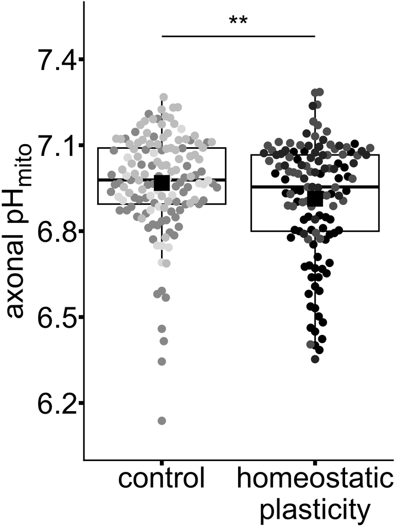

```r
set.seed(20261109)
date_levels <- levels(mito_df$Date)
date_colors <- c(
  setNames(rep(c("#999999", "#E0E0E0", "#C8C8C8"), length.out = length(date_levels)),
           paste("Control", date_levels, sep = "_")),
  setNames(rep(c("#000000", "#606060", "#303030"), length.out = length(date_levels)),
           paste("TTX", date_levels, sep = "_"))
)
stars <- case_when(condition_p < 0.001 ~ "***", condition_p < 0.01 ~ "**",
                   condition_p < 0.05 ~ "*", TRUE ~ "ns")
plot_stats <- tibble(x1 = 1, x2 = 2.2, y = 7.48, stars = stars) %>% filter(stars != "ns")

figs2d_plot <- ggplot(mito_df, aes(x_pos, Mito_pH, color = Date_Condition)) +
  geom_boxplot(aes(group = x_pos), fill = NA, width = 1, outlier.shape = NA,
               linewidth = 2, color = "black") +
  ggbeeswarm::geom_beeswarm(cex = 3, priority = "random", size = 10, corral = "random") +
  stat_summary(aes(group = x_pos), fun = mean, geom = "point",
               shape = 15, size = 20, color = "black") +
  geom_segment(data = plot_stats, aes(x = x1, xend = x2, y = y, yend = y),
               inherit.aes = FALSE, linewidth = 2, color = "black") +
  geom_text(data = plot_stats, aes(x = (x1 + x2) / 2, y = y + 0.04, label = stars),
            inherit.aes = FALSE, size = 25, color = "black") +
  scale_x_continuous(breaks = unname(spacing_map),
                     labels = c("control", "homeostatic\nplasticity")) +
  scale_y_continuous(oob = scales::oob_keep, breaks = c(6.2, 6.5, 6.8, 7.1, 7.4),
                     limits = c(6, 7.6), expand = c(0, 0)) +
  scale_color_manual(values = date_colors) +
  labs(x = NULL, y = "axonal pH<sub>mito</sub>") +
  theme_classic() +
  theme(axis.title.y = ggtext::element_markdown(size = 80, color = "black"),
        axis.text = element_text(size = 80, color = "black"),
        axis.ticks = element_line(linewidth = 5, color = "black"),
        axis.ticks.length = grid::unit(0.5, "cm"),
        axis.line = element_line(linewidth = 2, color = "black"),
        legend.position = "none")
figs2d_plot
```

# Fig S2E

Spine ATP reporter L/F measured with TTX maintained during imaging.

**Source data**  
`Fig S2E.csv`

**Columns**

- `Date` — Experiment date
- `Condition` — Control or TTX with TTX maintained during imaging
- `Dish` — Culture dish ID
- `Cell` — Cell ID
- `L` — Luciferase luminescence
- `F` — Reporter fluorescence
- `LbyF` — Luminescence-to-fluorescence ratio (L/F)

## Data

```r
suppressPackageStartupMessages({
  library(dplyr); library(readr); library(ggplot2); library(ggbeeswarm); library(ggtext)
})

spacing_map <- c(Control = 1, TTXinTTX = 2.2)
LbyF_df <- read_csv("./Fig S2E.csv", show_col_types = FALSE) %>%
  select(Date, Condition, Dish, Cell, L, F, LbyF) %>%
  mutate(Condition = trimws(as.character(Condition)),
         Condition = case_when(grepl("^Control", Condition, ignore.case = TRUE) ~ "Control",
                               grepl("^TTXinTTX", Condition, ignore.case = TRUE) ~ "TTXinTTX",
                               TRUE ~ Condition)) %>%
  filter(Condition %in% names(spacing_map), !is.na(Date), !is.na(Dish),
         !is.na(Cell), is.finite(LbyF)) %>%
  mutate(Condition = factor(Condition, levels = names(spacing_map)),
         Date = factor(Date), x_pos = unname(spacing_map[as.character(Condition)]),
         Date_Condition = paste(Condition, Date, sep = "_"))

if (nrow(LbyF_df) == 0) stop("No valid observations remain.")
LbyF_df %>% select(Date, Condition, Dish, Cell, L, F, LbyF) %>%
  mutate(across(where(is.numeric), ~ round(.x, 3)))
```

| Date | Condition | Dish | Cell | L | F | LbyF |
| --- | --- | --- | --- | --- | --- | --- |
| 2025-05-27 | Control | 1 | 1 | 133.762 | 642.714 | 0.208 |
| 2025-05-27 | Control | 1 | 1 | 157.000 | 819.048 | 0.192 |
| 2025-05-27 | Control | 1 | 1 | 70.619 | 428.333 | 0.165 |
| 2025-05-27 | Control | 1 | 1 | 110.762 | 707.952 | 0.156 |
| 2025-05-27 | Control | 1 | 1 | 118.857 | 595.381 | 0.200 |
| 2025-05-27 | Control | 1 | 1 | 134.619 | 707.095 | 0.190 |
| 2025-05-27 | Control | 1 | 1 | 154.238 | 856.524 | 0.180 |
| 2025-05-27 | Control | 1 | 2 | 141.381 | 826.857 | 0.171 |
| 2025-05-27 | Control | 1 | 2 | 136.048 | 690.238 | 0.197 |
| 2025-05-27 | Control | 1 | 2 | 85.619 | 480.190 | 0.178 |

[output cut: 662 more lines]

## Summary

```r
summary_table <- LbyF_df %>%
  group_by(Condition) %>%
  summarise(n_Spines = n(), n_Cells = n_distinct(Date, Dish, Cell),
            n_Experiment_Dates = n_distinct(Date), .groups = "drop")
summary_table
```

| Condition | n_Spines | n_Cells | n_Experiment_Dates |
| --- | --- | --- | --- |
| Control | 343 | 38 | 3 |
| TTXinTTX | 329 | 20 | 3 |

## Statistics

Two-way ANOVA with condition, experiment date, and their interaction (Type I sums of squares).

```r
fit_aov <- aov(LbyF ~ Condition * Date, data = LbyF_df)
condition_p <- as.numeric(anova(fit_aov)["Condition", "Pr(>F)"])
format_p <- function(p) ifelse(p < 0.0001, "<0.0001", sprintf("%.4f", p))

means <- LbyF_df %>% group_by(Condition) %>%
  summarise(mean = mean(LbyF), SE = sd(LbyF) / sqrt(n()), .groups = "drop")
stats_table <- tibble(
  Test = "Two-way ANOVA", Comparison = "Control vs TTXinTTX",
  `Control mean (SE)` = sprintf("%.3f (%.3f)", means$mean[1], means$SE[1]),
  `TTXinTTX mean (SE)` = sprintf("%.3f (%.3f)", means$mean[2], means$SE[2]),
  `Condition p` = format_p(condition_p)
)
stats_table
```

| Test | Comparison | Control mean (SE) | TTXinTTX mean (SE) | Condition p |
| --- | --- | --- | --- | --- |
| Two-way ANOVA | Control vs TTXinTTX | 0.152 (0.003) | 0.245 (0.008) | <0.0001 |

```r
anova(fit_aov)
```

|  | Df | Sum Sq | Mean Sq | F value | Pr(>F) |
| --- | --- | --- | --- | --- | --- |
| Condition | 1 | 1.4435214 | 1.443521410 | 147.07797 | 1.003074e-30 |
| Date | 2 | 1.6389917 | 0.819495829 | 83.49706 | 4.396989e-33 |
| Condition:Date | 2 | 0.5165051 | 0.258252549 | 26.31292 | 1.003406e-11 |
| Residuals | 666 | 6.5365685 | 0.009814667 | NA | NA |

## Plot

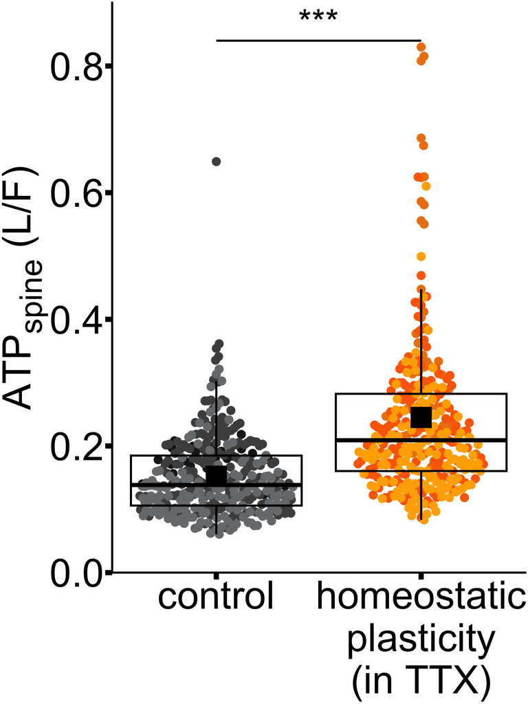

```r
set.seed(20261109)
date_levels <- levels(LbyF_df$Date)
date_colors <- c(
  setNames(rep(c("#1A1A1A", "#4D4D4D", "#777B7E"), length.out = length(date_levels)),
           paste("Control", date_levels, sep = "_")),
  setNames(rep(c("#ED820E", "#FC6A03", "#FFAD00"), length.out = length(date_levels)),
           paste("TTXinTTX", date_levels, sep = "_"))
)
stars <- case_when(condition_p < 0.001 ~ "***", condition_p < 0.01 ~ "**",
                   condition_p < 0.05 ~ "*", TRUE ~ "ns")
plot_stats <- tibble(x1 = 1, x2 = 2.2, y = 0.84, stars = stars) %>% filter(stars != "ns")

figs2e_plot <- ggplot(LbyF_df, aes(x_pos, LbyF, color = Date_Condition)) +
  ggbeeswarm::geom_beeswarm(cex = 1.5, priority = "random", size = 8, corral = "random") +
  geom_boxplot(aes(group = x_pos), fill = NA, width = 1, outlier.shape = NA,
               linewidth = 2, color = "black") +
  stat_summary(aes(group = x_pos), fun = mean, geom = "point",
               shape = 15, size = 20, color = "black") +
  geom_segment(data = plot_stats, aes(x = x1, xend = x2, y = y, yend = y),
               inherit.aes = FALSE, linewidth = 2, color = "black") +
  geom_text(data = plot_stats, aes(x = (x1 + x2) / 2, y = y + 0.03, label = stars),
            inherit.aes = FALSE, size = 25, color = "black") +
  scale_x_continuous(breaks = unname(spacing_map),
                     labels = c("control", "homeostatic\nplasticity\n(in TTX)")) +
  scale_y_continuous(breaks = c(0, 0.2, 0.4, 0.6, 0.8), expand = c(0, 0)) +
  scale_color_manual(values = date_colors) +
  coord_cartesian(ylim = c(0, 0.9)) +
  labs(x = NULL, y = "ATP<sub>spine</sub> (L/F)") +
  theme_classic() +
  theme(axis.title.y = ggtext::element_markdown(size = 80, color = "black"),
        axis.text = element_text(size = 80, color = "black"),
        axis.ticks = element_line(linewidth = 5, color = "black"),
        axis.ticks.length = grid::unit(0.5, "cm"),
        axis.line = element_line(linewidth = 2, color = "black"),
        legend.position = "none")
figs2e_plot
```

# Fig S2F

Spine pH following homeostatic plasticity in wild-type neurons.

**Source data**  
`Fig S2F.csv`

**Columns**

- `Date` — Experiment date
- `Condition` — Control or TTX
- `Dish` — Culture dish ID
- `Cell` — Cell ID
- `Spine_ID` — Spine trace ID
- `Frame` — Imaging frame
- `Intensity` — pH sensor fluorescence

## Data

pH is estimated per trace using mean fluorescence over the first ten frames, peak fluorescence, pKa 7.1, and a reference pH of 7.4.

```r
suppressPackageStartupMessages({
  library(dplyr); library(readr); library(ggplot2); library(ggbeeswarm); library(ggtext)
})

spacing_map <- c(Control = 1, TTX = 2.2)
pKa <- 7.1

pH_df <- read_csv("./Fig S2F.csv", show_col_types = FALSE) %>%
  filter(Condition %in% names(spacing_map), is.finite(Frame), is.finite(Intensity)) %>%
  group_by(Date, Condition, Dish, Cell, Spine_ID, Frame) %>%
  summarise(Intensity = mean(Intensity), .groups = "drop")

spine_df <- pH_df %>%
  group_by(Date, Condition, Dish, Cell, Spine_ID) %>%
  summarise(n_Frames = n_distinct(Frame),
            F0 = mean(Intensity[Frame %in% head(sort(unique(Frame)), 10)]),
            Fmax = max(Intensity), .groups = "drop") %>%
  filter(n_Frames >= 10, F0 > 0, Fmax > 0) %>%
  mutate(Spine_pH = pKa - log10((1 + 10^(pKa - 7.4)) / (F0 / Fmax) - 1)) %>%
  filter(is.finite(Spine_pH)) %>%
  mutate(Condition = factor(Condition, levels = names(spacing_map)),
         Date = factor(Date), x_pos = unname(spacing_map[as.character(Condition)]),
         Date_Condition = paste(Condition, Date, sep = "_"))

if (nrow(spine_df) == 0) stop("No valid spines remain.")
spine_df %>% transmute(Date, Condition, Dish, Cell, Spine_ID, Spine_pH = round(Spine_pH, 3))
```

| Date | Condition | Dish | Cell | Spine_ID | Spine_pH |
| --- | --- | --- | --- | --- | --- |
| 2025-06-25 | Control | 1 | 1 | 1 | 6.818 |
| 2025-06-25 | Control | 1 | 1 | 2 | 6.808 |
| 2025-06-25 | Control | 1 | 1 | 3 | 6.808 |
| 2025-06-25 | Control | 1 | 1 | 4 | 6.697 |
| 2025-06-25 | Control | 2 | 1 | 1 | 7.051 |
| 2025-06-25 | Control | 2 | 1 | 2 | 6.992 |
| 2025-06-25 | Control | 2 | 1 | 3 | 6.873 |
| 2025-06-25 | Control | 3 | 1 | 1 | 6.966 |
| 2025-06-25 | Control | 3 | 1 | 2 | 7.282 |
| 2025-06-25 | Control | 3 | 1 | 3 | 7.107 |

[output cut: 82 more lines]

## Summary

```r
summary_table <- spine_df %>%
  group_by(Condition) %>%
  summarise(n_Spines = n(), n_Cells = n_distinct(Date, Dish, Cell),
            n_Experiment_Dates = n_distinct(Date), .groups = "drop")
summary_table
```

| Condition | n_Spines | n_Cells | n_Experiment_Dates |
| --- | --- | --- | --- |
| Control | 60 | 9 | 3 |
| TTX | 32 | 7 | 3 |

## Statistics

Two-way ANOVA with condition, experiment date, and their interaction (Type I sums of squares).

```r
fit_aov <- aov(Spine_pH ~ Condition * Date, data = spine_df)
condition_p <- as.numeric(anova(fit_aov)["Condition", "Pr(>F)"])
format_p <- function(p) ifelse(p < 0.0001, "<0.0001", sprintf("%.4f", p))

means <- spine_df %>% group_by(Condition) %>%
  summarise(mean = mean(Spine_pH), SE = sd(Spine_pH) / sqrt(n()), .groups = "drop")
stats_table <- tibble(
  Test = "Two-way ANOVA", Comparison = "Control vs TTX",
  `Control mean (SE)` = sprintf("%.3f (%.3f)", means$mean[1], means$SE[1]),
  `TTX mean (SE)` = sprintf("%.3f (%.3f)", means$mean[2], means$SE[2]),
  `Condition p` = format_p(condition_p)
)
stats_table
```

| Test | Comparison | Control mean (SE) | TTX mean (SE) | Condition p |
| --- | --- | --- | --- | --- |
| Two-way ANOVA | Control vs TTX | 6.948 (0.022) | 6.742 (0.049) | <0.0001 |

```r
anova(fit_aov)
```

|  | Df | Sum Sq | Mean Sq | F value | Pr(>F) |
| --- | --- | --- | --- | --- | --- |
| Condition | 1 | 0.8868585 | 0.88685854 | 21.404017 | 1.303913e-05 |
| Date | 2 | 0.3124392 | 0.15621960 | 3.770305 | 2.694170e-02 |
| Condition:Date | 2 | 0.1740660 | 0.08703302 | 2.100511 | 1.286295e-01 |
| Residuals | 86 | 3.5633421 | 0.04143421 | NA | NA |

## Plot

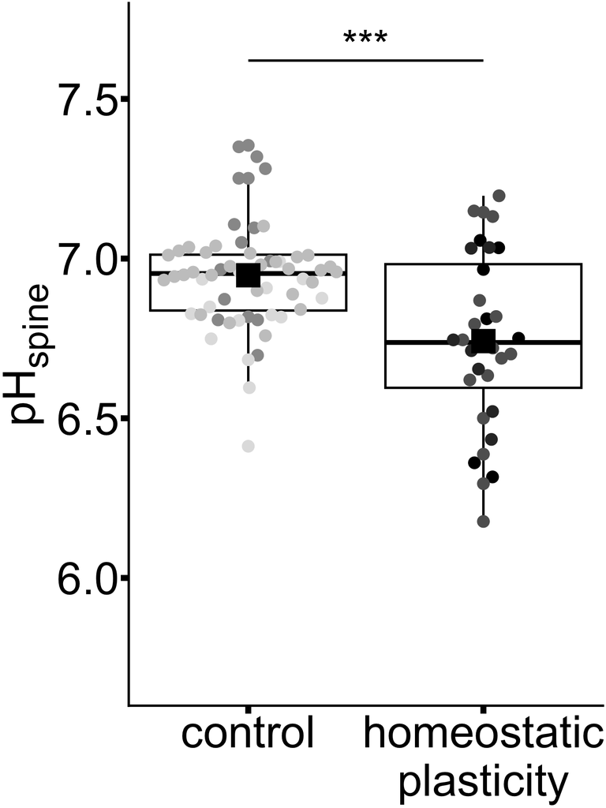

```r
set.seed(20261109)
date_levels <- levels(spine_df$Date)
date_colors <- c(
  setNames(rep(c("#999999", "#E0E0E0", "#C8C8C8"), length.out = length(date_levels)),
           paste("Control", date_levels, sep = "_")),
  setNames(rep(c("#000000", "#606060", "#303030"), length.out = length(date_levels)),
           paste("TTX", date_levels, sep = "_"))
)
stars <- case_when(condition_p < 0.001 ~ "***", condition_p < 0.01 ~ "**",
                   condition_p < 0.05 ~ "*", TRUE ~ "ns")
plot_stats <- tibble(x1 = 1, x2 = 2.2, y = 7.62, stars = stars) %>% filter(stars != "ns")

figs2f_plot <- ggplot(spine_df, aes(x_pos, Spine_pH, color = Date_Condition)) +
  geom_boxplot(aes(group = x_pos), fill = NA, width = 1, outlier.shape = NA,
               linewidth = 2, color = "black") +
  ggbeeswarm::geom_beeswarm(cex = 4, priority = "random", size = 10, corral = "random") +
  stat_summary(aes(group = x_pos), fun = mean, geom = "point",
               shape = 15, size = 20, color = "black") +
  geom_segment(data = plot_stats, aes(x = x1, xend = x2, y = y, yend = y),
               inherit.aes = FALSE, linewidth = 2, color = "black") +
  geom_text(data = plot_stats, aes(x = (x1 + x2) / 2, y = y + 0.05, label = stars),
            inherit.aes = FALSE, size = 25, color = "black") +
  scale_x_continuous(breaks = unname(spacing_map),
                     labels = c("control", "homeostatic\nplasticity")) +
  scale_y_continuous(oob = scales::oob_keep, breaks = c(6, 6.5, 7, 7.5),
                     limits = c(5.6, 7.8), expand = c(0, 0)) +
  scale_color_manual(values = date_colors) +
  labs(x = NULL, y = "pH<sub>spine</sub>") +
  theme_classic() +
  theme(axis.title.y = ggtext::element_markdown(size = 80, color = "black"),
        axis.text = element_text(size = 80, color = "black"),
        axis.ticks = element_line(linewidth = 5, color = "black"),
        axis.ticks.length = grid::unit(0.5, "cm"),
        axis.line = element_line(linewidth = 2, color = "black"),
        legend.position = "none")
figs2f_plot
```

# Fig S2G

Spine pH following homeostatic plasticity after MPC1 knockdown.

**Source data**  
`Fig S2G.csv`

**Columns**

- `Date` — Experiment date
- `Condition` — Control or TTX after MPC1 knockdown
- `Dish` — Culture dish ID
- `Cell` — Cell ID
- `Spine_ID` — Spine trace ID
- `Frame` — Imaging frame
- `Intensity` — pH sensor fluorescence

## Data

pH is estimated per trace using mean fluorescence over the first ten frames, peak fluorescence, pKa 7.1, and a reference pH of 7.4.

```r
suppressPackageStartupMessages({
  library(dplyr); library(readr); library(ggplot2); library(ggbeeswarm); library(ggtext)
})

spacing_map <- c("Control MPC1KD" = 1, "TTX MPC1KD" = 2.2)
pKa <- 7.1

pH_df <- read_csv("./Fig S2G.csv", show_col_types = FALSE) %>%
  filter(Condition %in% names(spacing_map), is.finite(Frame), is.finite(Intensity)) %>%
  group_by(Date, Condition, Dish, Cell, Spine_ID, Frame) %>%
  summarise(Intensity = mean(Intensity), .groups = "drop")

spine_df <- pH_df %>%
  group_by(Date, Condition, Dish, Cell, Spine_ID) %>%
  summarise(n_Frames = n_distinct(Frame),
            F0 = mean(Intensity[Frame %in% head(sort(unique(Frame)), 10)]),
            Fmax = max(Intensity), .groups = "drop") %>%
  filter(n_Frames >= 10, F0 > 0, Fmax > 0) %>%
  mutate(Spine_pH = pKa - log10((1 + 10^(pKa - 7.4)) / (F0 / Fmax) - 1)) %>%
  filter(is.finite(Spine_pH)) %>%
  mutate(Condition = factor(Condition, levels = names(spacing_map)),
         Date = factor(Date), x_pos = unname(spacing_map[as.character(Condition)]),
         Date_Condition = paste(Condition, Date, sep = "_"))

if (nrow(spine_df) == 0) stop("No valid spines remain.")
spine_df %>% transmute(Date, Condition, Dish, Cell, Spine_ID, Spine_pH = round(Spine_pH, 3))
```

| Date | Condition | Dish | Cell | Spine_ID | Spine_pH |
| --- | --- | --- | --- | --- | --- |
| 2026-05-28 | Control MPC1KD | 1 | 1 | 1 | 6.755 |
| 2026-05-28 | Control MPC1KD | 1 | 1 | 2 | 7.278 |
| 2026-05-28 | Control MPC1KD | 1 | 1 | 3 | 7.039 |
| 2026-05-28 | Control MPC1KD | 1 | 1 | 4 | 6.547 |
| 2026-05-28 | Control MPC1KD | 1 | 1 | 5 | 6.627 |
| 2026-05-28 | Control MPC1KD | 1 | 1 | 6 | 7.140 |
| 2026-05-28 | Control MPC1KD | 1 | 1 | 7 | 7.170 |
| 2026-05-28 | Control MPC1KD | 1 | 1 | 8 | 6.955 |
| 2026-05-28 | Control MPC1KD | 1 | 1 | 9 | 6.666 |
| 2026-05-28 | Control MPC1KD | 1 | 1 | 10 | 6.754 |

[output cut: 188 more lines]

## Summary

```r
summary_table <- spine_df %>%
  group_by(Condition) %>%
  summarise(n_Spines = n(), n_Cells = n_distinct(Date, Dish, Cell),
            n_Experiment_Dates = n_distinct(Date), .groups = "drop")
summary_table
```

| Condition | n_Spines | n_Cells | n_Experiment_Dates |
| --- | --- | --- | --- |
| Control MPC1KD | 78 | 7 | 3 |
| TTX MPC1KD | 120 | 8 | 3 |

## Statistics

Two-way ANOVA with condition, experiment date, and their interaction (Type I sums of squares).

```r
fit_aov <- aov(Spine_pH ~ Condition * Date, data = spine_df)
condition_p <- as.numeric(anova(fit_aov)["Condition", "Pr(>F)"])
format_p <- function(p) ifelse(p < 0.0001, "<0.0001", sprintf("%.4f", p))

means <- spine_df %>% group_by(Condition) %>%
  summarise(mean = mean(Spine_pH), SE = sd(Spine_pH) / sqrt(n()), .groups = "drop")
stats_table <- tibble(
  Test = "Two-way ANOVA", Comparison = "Control MPC1KD vs TTX MPC1KD",
  `Control mean (SE)` = sprintf("%.3f (%.3f)", means$mean[1], means$SE[1]),
  `TTX mean (SE)` = sprintf("%.3f (%.3f)", means$mean[2], means$SE[2]),
  `Condition p` = format_p(condition_p)
)
stats_table
```

| Test | Comparison | Control mean (SE) | TTX mean (SE) | Condition p |
| --- | --- | --- | --- | --- |
| Two-way ANOVA | Control MPC1KD vs TTX MPC1KD | 6.920 (0.030) | 6.868 (0.029) | 0.1661 |

```r
anova(fit_aov)
```

|  | Df | Sum Sq | Mean Sq | F value | Pr(>F) |
| --- | --- | --- | --- | --- | --- |
| Condition | 1 | 0.1268529 | 0.12685291 | 1.932712 | 1.660716e-01 |
| Date | 2 | 2.2560298 | 1.12801492 | 17.186267 | 1.360943e-07 |
| Condition:Date | 2 | 2.1518296 | 1.07591481 | 16.392477 | 2.674626e-07 |
| Residuals | 192 | 12.6018565 | 0.06563467 | NA | NA |

## Plot

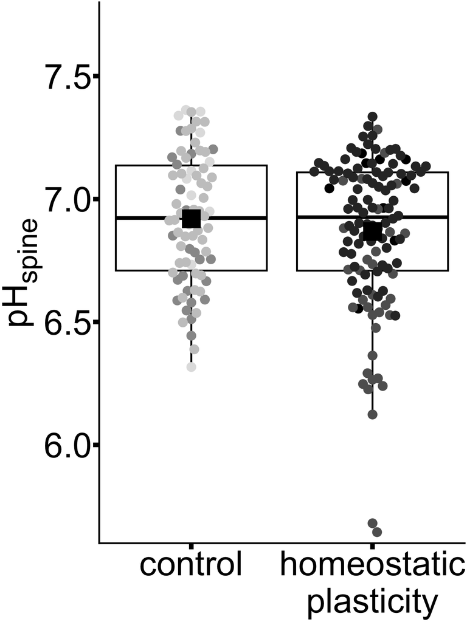

```r
set.seed(20261109)
date_levels <- levels(spine_df$Date)
date_colors <- c(
  setNames(rep(c("#999999", "#E0E0E0", "#C8C8C8"), length.out = length(date_levels)),
           paste("Control MPC1KD", date_levels, sep = "_")),
  setNames(rep(c("#000000", "#606060", "#303030"), length.out = length(date_levels)),
           paste("TTX MPC1KD", date_levels, sep = "_"))
)
stars <- case_when(condition_p < 0.001 ~ "***", condition_p < 0.01 ~ "**",
                   condition_p < 0.05 ~ "*", TRUE ~ "ns")
plot_stats <- tibble(x1 = 1, x2 = 2.2, y = 7.62, stars = stars) %>% filter(stars != "ns")

figs2g_plot <- ggplot(spine_df, aes(x_pos, Spine_pH, color = Date_Condition)) +
  geom_boxplot(aes(group = x_pos), fill = NA, width = 1, outlier.shape = NA,
               linewidth = 2, color = "black") +
  ggbeeswarm::geom_beeswarm(cex = 3, priority = "random", size = 10, corral = "random") +
  stat_summary(aes(group = x_pos), fun = mean, geom = "point",
               shape = 15, size = 20, color = "black") +
  geom_segment(data = plot_stats, aes(x = x1, xend = x2, y = y, yend = y),
               inherit.aes = FALSE, linewidth = 2, color = "black") +
  geom_text(data = plot_stats, aes(x = (x1 + x2) / 2, y = y + 0.05, label = stars),
            inherit.aes = FALSE, size = 25, color = "black") +
  scale_x_continuous(breaks = unname(spacing_map),
                     labels = c("control", "homeostatic\nplasticity")) +
  scale_y_continuous(oob = scales::oob_keep, breaks = c(6, 6.5, 7, 7.5),
                     limits = c(5.6, 7.8), expand = c(0, 0)) +
  scale_color_manual(values = date_colors) +
  labs(x = NULL, y = "pH<sub>spine</sub>") +
  theme_classic() +
  theme(axis.title.y = ggtext::element_markdown(size = 80, color = "black"),
        axis.text = element_text(size = 80, color = "black"),
        axis.ticks = element_line(linewidth = 5, color = "black"),
        axis.ticks.length = grid::unit(0.5, "cm"),
        axis.line = element_line(linewidth = 2, color = "black"),
        legend.position = "none")
figs2g_plot
```

# Fig S2H

Regional mitochondrial pH time courses used to correct the ATP traces in Fig 2K.

**update for 2026 pending** — The source contains regional means and SEs. Individual pH traces and replicate IDs are unavailable.

**Source data**  
`Fig S2H.csv`, `Fig S2H uninduced.csv`

**Columns**

- `Time` — Time relative to induction (min)
- `Juxta` — Mean juxtaspinal mitochondrial pH
- `Juxta_SE` — SE of the corresponding mean pH
- `NonJuxta` — Mean non-juxtaspinal mitochondrial pH
- `NonJuxta_SE` — SE of the corresponding mean pH
- `Unstim` — Mean mitochondrial pH near uninduced spines
- `Unstim_SE` — SE of the corresponding mean pH

## Data

Regional means and SEs are aligned by time. The uninduced-spine trace comes from the Figure 2K pH correction data.

```r
suppressPackageStartupMessages({
  library(dplyr); library(readr); library(ggplot2)
})

N_BASELINE_POINTS <- 9
region_order <- c("Juxta", "NonJuxta", "Unstim")
region_colors <- c(Juxta = "#1A1A1A", NonJuxta = "#777B7E", Unstim = "#BDBDBD")
X_BREAKS <- ERRORBAR_TIMES <- c(-2, 0, 2, 4, 6, 8, 10, 12)

pH_wide <- read_csv("./Fig S2H.csv", show_col_types = FALSE) %>%
  left_join(read_csv("./Fig S2H uninduced.csv",show_col_types=FALSE),by="Time")
required <- c("Time", "Juxta", "NonJuxta", "Juxta_SE", "NonJuxta_SE", "Unstim", "Unstim_SE")
if (length(setdiff(required, names(pH_wide)))) stop("Fig S2H.csv is missing required columns.")

pH_data <- bind_rows(
  pH_wide %>% transmute(Time = as.numeric(Time), region = "Juxta",
                         pH = as.numeric(Juxta), SE = as.numeric(Juxta_SE), time_order = row_number()),
  pH_wide %>% transmute(Time = as.numeric(Time), region = "NonJuxta",
                         pH = as.numeric(NonJuxta), SE = as.numeric(NonJuxta_SE), time_order = row_number()),
  pH_wide %>% transmute(Time=as.numeric(Time),region="Unstim",pH=as.numeric(Unstim),
                         SE=as.numeric(Unstim_SE),time_order=row_number())
) %>%
  filter(is.finite(Time), is.finite(pH)) %>%
  mutate(region = factor(region, levels = region_order),
         BaselinePoint = time_order <= N_BASELINE_POINTS) %>%
  arrange(region, time_order)

if (any(pH_data %>% filter(BaselinePoint) %>% count(region) %>% pull(n) != N_BASELINE_POINTS) ||
    n_distinct(pH_data$region) != 3) stop("All three regions need nine baseline measurements.")

pH_data %>% select(Time, region, pH, SE) %>%
  mutate(across(where(is.numeric), ~ round(.x, 3)))
```

| Time | region | pH | SE |
| --- | --- | --- | --- |
| -2.66 | Juxta | 7.117 | 0.040 |
| -2.33 | Juxta | 7.141 | 0.045 |
| -2.00 | Juxta | 7.136 | 0.048 |
| -1.66 | Juxta | 7.145 | 0.042 |
| -1.33 | Juxta | 7.160 | 0.040 |
| -1.00 | Juxta | 7.168 | 0.045 |
| -0.66 | Juxta | 7.176 | 0.039 |
| -0.33 | Juxta | 7.169 | 0.039 |
| 0.00 | Juxta | 7.171 | 0.045 |
| 2.00 | Juxta | 7.003 | 0.033 |

[output cut: 110 more lines]

## Summary

```r
baseline_table <- pH_data %>%
  filter(BaselinePoint) %>%
  group_by(region) %>%
  summarise(`Baseline mean pH` = round(mean(pH), 3), .groups = "drop")
baseline_table
```

| region | Baseline mean pH |
| --- | --- |
| Juxta | 7.154 |
| NonJuxta | 7.002 |
| Unstim | 7.002 |

```r
summary_table <- pH_data %>% count(region,name="n_Timepoints")
summary_table
```

| region | n_Timepoints |
| --- | --- |
| Juxta | 40 |
| NonJuxta | 40 |
| Unstim | 40 |

## Statistics

Mean ± SE.

## Plot

The red bar marks single-spine induction from 0 to 2 min.

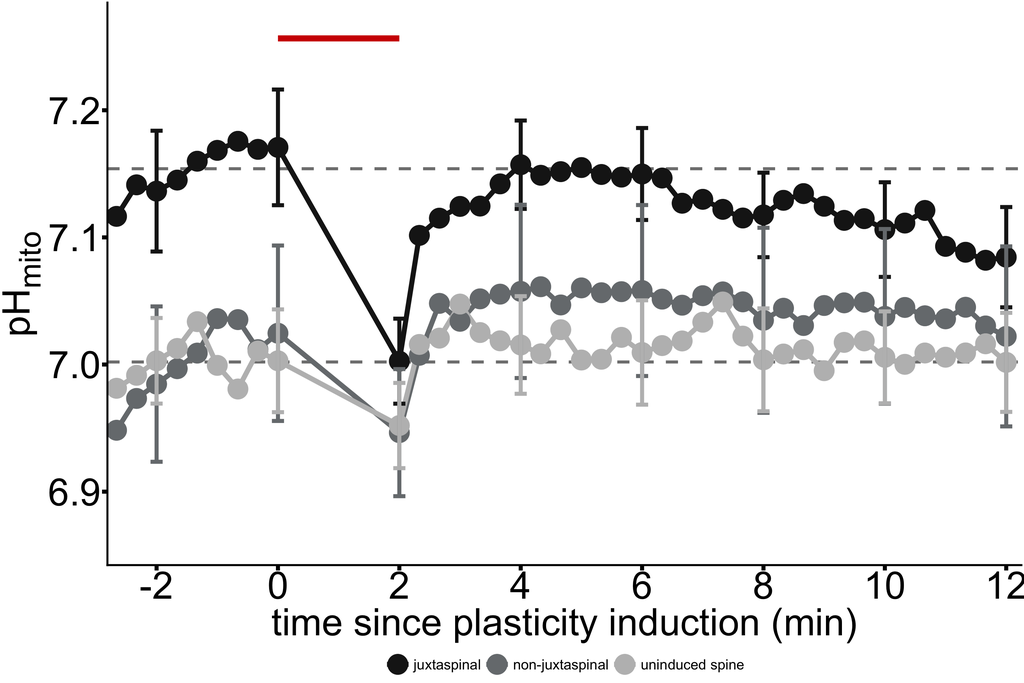

```r
set.seed(20261109)
baseline_lines <- baseline_table %>%
  transmute(region, baseline_value = `Baseline mean pH`)
pH_errorbars <- pH_data %>%
  filter(round(Time, 8) %in% round(ERRORBAR_TIMES, 8), is.finite(SE))

data_min <- min(pH_data$pH - ifelse(is.finite(pH_data$SE), pH_data$SE, 0))
data_max <- max(pH_data$pH + ifelse(is.finite(pH_data$SE), pH_data$SE, 0))
data_range <- max(data_max - data_min, 0.05)
y_limits <- c(data_min - 0.1 * data_range, data_max + 0.15 * data_range)

figs2h_plot <- ggplot(pH_data, aes(Time, pH, color = region, group = region)) +
  geom_hline(data = baseline_lines, aes(yintercept = baseline_value),
             inherit.aes = FALSE, color = "grey50", linetype = "dashed", linewidth = 3) +
  geom_line(linewidth = 5) +
  geom_point(size = 20) +
  geom_errorbar(data = pH_errorbars, aes(ymin = pH - SE, ymax = pH + SE),
                width = 0.2, linewidth = 4) +
  scale_color_manual(values = region_colors, breaks = region_order, labels = c("juxtaspinal","non-juxtaspinal","uninduced spine")) +
  scale_x_continuous(breaks = X_BREAKS, expand = expansion(add = c(0.15, 0.15))) +
  scale_y_continuous(oob = scales::oob_keep, limits = y_limits) +
  labs(x = "time since plasticity induction (min)", y = "pH<sub>mito</sub>") +
  annotate("segment",x=0,xend=2,y=y_limits[2] - 0.02 * diff(y_limits),yend=y_limits[2] - 0.02 * diff(y_limits),color="#D00000",linewidth=6) +
  theme_classic() +
  theme(
    axis.title.x = element_text(size = 80, color = "black"),
    axis.title.y = ggtext::element_markdown(size = 80, color = "black"),
    axis.text = element_text(size = 80, color = "black"),
    axis.ticks = element_line(linewidth = 4, color = "black"),
    axis.ticks.length = grid::unit(0.4, "cm"),
    axis.line = element_line(linewidth = 2, color = "black"),
    legend.position = "bottom", legend.text = element_text(size=30), legend.title = element_blank()
  )
figs2h_plot
```